# Galamsey

Spatial Distribution, Clustering, and Evidence for Economic Spillovers

2026-07-01

## Overview

**Data:** Barenblitt et al. (2021) remote-sensing panel — mine extent polygons, annual 2007–2017, SW Ghana (~104,730 km²)

**Unit of analysis:** 5 km hexagonal grid covering the study region

**Questions:**

1. **Where?** Spatial distribution of galamsey across SW Ghana
2. **Clustered?** Statistical evidence for spatial autocorrelation
3. **Why clustered?** Geography vs. social and economic drivers
4. **Spreading?** Evidence for economic spillovers along river corridors

**Core question:** Is the spatial clustering of galamsey explained by underlying geography (gold geology, river networks), or is there evidence of social and economic spillover processes?

## What’s New Since June 10

# Part 1

Where does galamsey happen?

## Data: Barenblitt et al. (2021)

**Remote-sensing derived mine extent, SW Ghana**

- **Annual time series:** 2007–2017, new conversions per year
- **Full 2019 extent:** artisanal vs industrial mining
- Classified from Landsat imagery, Random Forest model
- **Coverage:** SW Ghana only (~104,730 km²) — northern districts have no data, not zero mines
- **Accuracy:** Producer accuracy 75.6% — ~1 in 4 real mines missed; treat as positive labels only; absence ≠ no mining

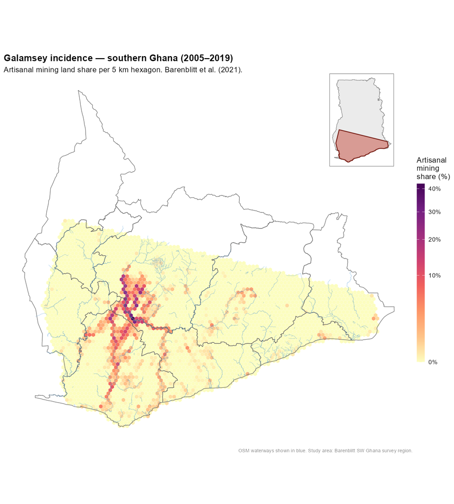

## Fine-Scale Incidence — 5 km Hexagons

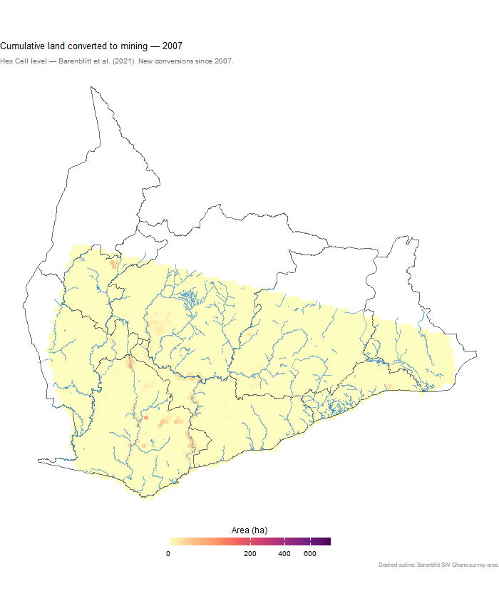

Cumulative artisanal mining land cover per 5 km hexagon, animated 2007–2017. Tight spatial clustering is evident within and across district boundaries.

## Artisanal vs Industrial Mining — 5 km Hexagons

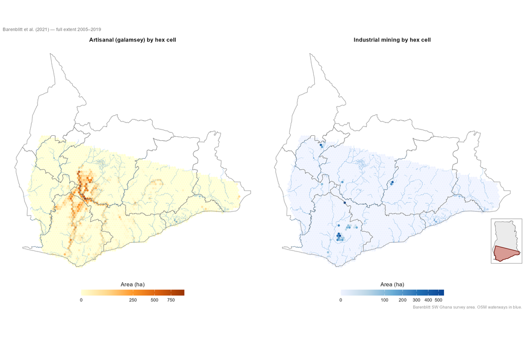

Left: artisanal (galamsey). Right: industrial (formal). 5 km hexagons. Note the divergent spatial footprints — artisanal mining is more dispersed and river-proximate; industrial mining concentrates in fewer, larger sites. Barenblitt 2019 extent.

## District-Level Extent

**Galamsey is widespread across SW Ghana**

- **167 of Ghana’s 260 districts** fall within the Barenblitt survey area
- Artisanal mining is recorded across the full survey area — galamsey is not confined to a handful of hotspots
- The remaining 93 districts have no coverage: absent data means *no survey*, not zero mines
- **Highly concentrated:** the top 10% of districts (~17) account for **94% of total artisanal mining extent**

🔍 *Click the figure to enlarge.*

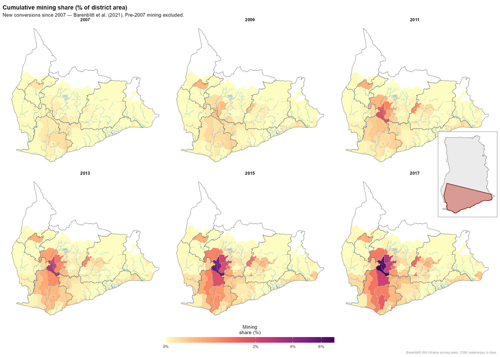

# Part 2

Is galamsey spatially clustered?

## Global Moran’s I: Is Clustering Statistically Significant?

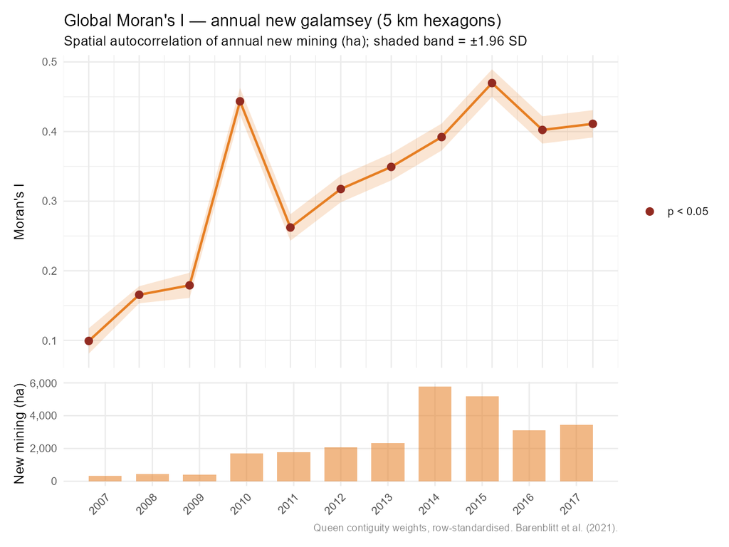

Global Moran’s I on annual new mining (ha) per 5 km hexagon, 2007–2017. Queen contiguity weights, row-standardised. Red = p < 0.05. Moran’s I consistently positive and significant — new mining is not randomly distributed across space.

## LISA Clusters: Where Are the Hotspots?

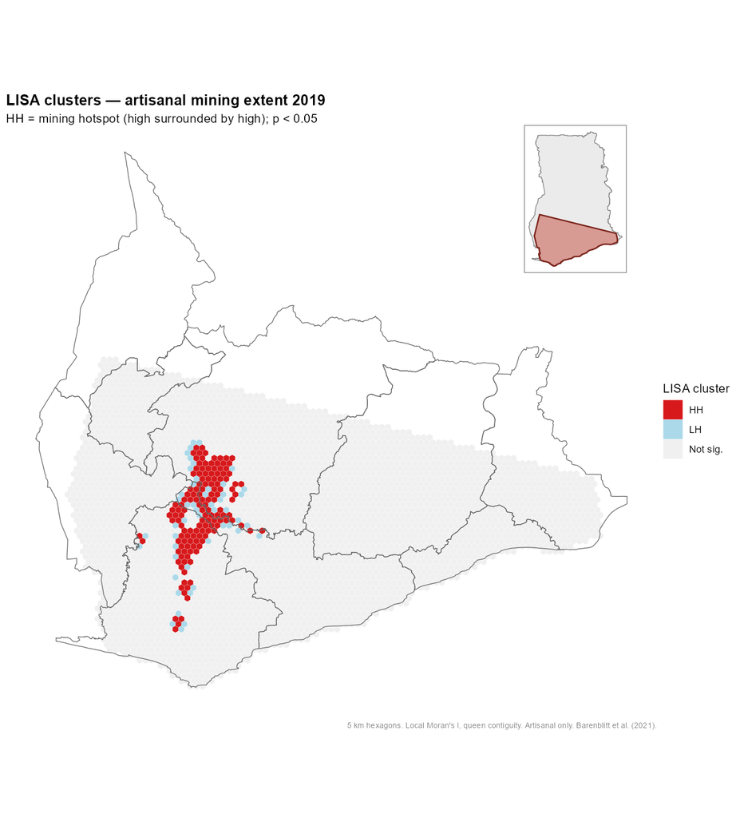

# Part 3

What drives the clustering?

## Decomposing Spatial Clustering

The observed spatial autocorrelation has two components:

$$I_{\text{observed}} \;=\; \underbrace{I_{\text{geography}}}_{\substack{\text{clustering due to}\\\text{geography}}} \;+\; \underbrace{I_{\text{excess}}}_{\substack{\text{excess clustering}\\\text{(unexplained)}}}$$

- **$I_{\text{geography}}$** — mines tend to locate where geology and river networks make mining viable. This produces spatial concentration, but not necessarily neighbour-to-neighbour spillover.
- **$I_{\text{excess}}$** — mines cluster *more than geography alone can explain*. Consistent with social and economic spillover processes: labour mobility, information diffusion, reduced enforcement risk.
- **Strategy:** (1) confirm geography is a genuine predictor (first stage); (2) show that residual clustering far exceeds what the richest geography null — including an unrestricted spatial spline (M5) — can account for.

## Gold-Suitable Geology and Artisanal Mining

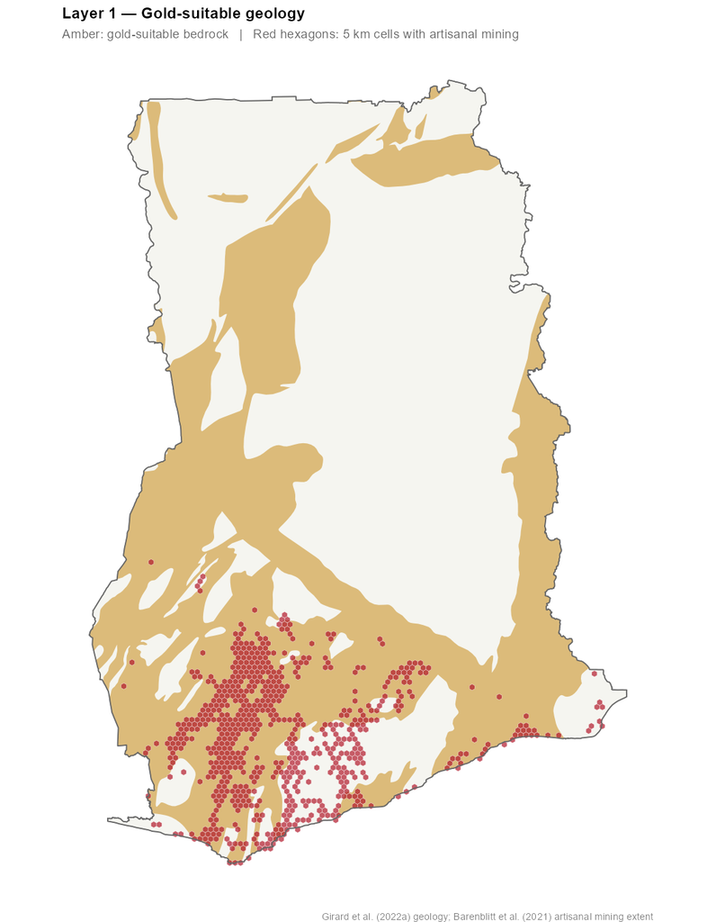

Amber: gold-suitable bedrock (Girard et al. 2022a, Layer 1 — CGMW-BRGM 1:10M geological map). Red hexagons: 5 km cells with artisanal mining (Barenblitt et al. 2021, 2019 extent).

## Geography as a Predictor: First Stage

|  | Any artisanal mining (0/1) |
| --- | --- |
| Distance to nearest river (km) | -0.0072*** |
|  | (0.00169) |
| Gold-suitable geology (share of hex) | 0.0378** |
|  | (0.0158) |
| Observations | 3,348 |
| R² | 0.00845 |
| Joint F-stat | 14.3 |

LPM, 5 km hexes, robust SEs. *** *p* < 0.01.

- **River proximity:** mining concentrates near waterways — alluvial gold deposits and water requirements of artisanal processing.
- **Gold geology:** hexes on gold-suitable ground show higher mine incidence — consistent with ore-targeting.
- Low *R²*: geography explains *where*, not *why* mines cluster.

## Terrain Covariates: Elevation and Slope

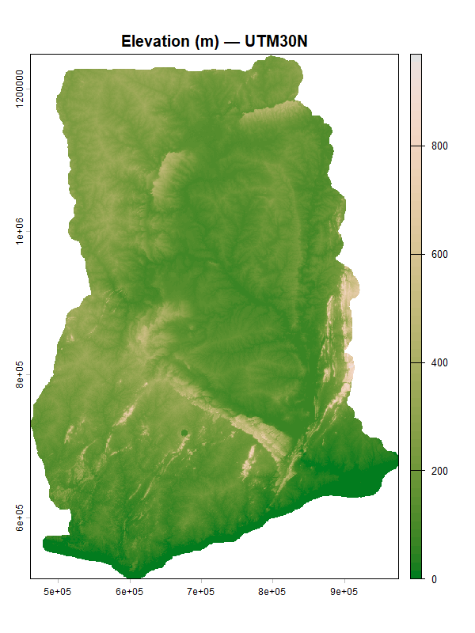

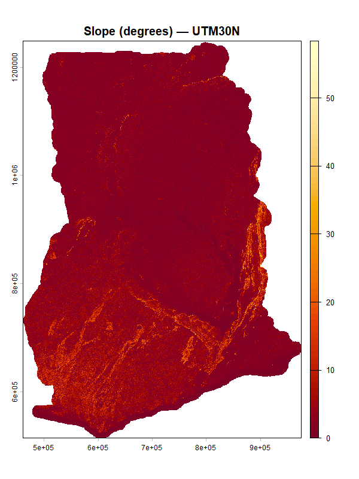

Elevation (left) and slope in degrees (right), Ghana, UTM30N. AWS Terrain Tiles z11 (~76 m).

## Building the Geography Control: M1 → M4

- **M1** — first-stage geography: distance to river + gold suitability
- **M2** — adds a flexible spline for river proximity (non-linear distance-to-river) and spatial lags of both covariates
- **M3** — adds terrain (elevation, slope)
- **M4** — adds interactions

| Model | Covariates | AUC | McFadden R² | p (excess) |
| --- | --- | --- | --- | --- |
| M1 | Baseline (geology + river) | 0.590 | 0.0089 | < 0.002 |
| M2 | + river spline + spatial lags | 0.605 | 0.0229 | < 0.002 |
| M3 | + terrain (elev + slope) | 0.676 | 0.0665 | < 0.002 |
| M4 | + interactions (all 4) | 0.684 | 0.0725 | < 0.002 |

5 km hexes. Fit rises M1→M4 yet *p* (excess) ≈ 0 throughout. Robust at 1 km and 2 km (MAUP).

## Ruling Out Unobserved Geography: The Spatial Spline (M5)

$$\text{logit}\,P(\text{mine}_i) = \underbrace{X_i\beta}_{\text{M4 covariates}} + \underbrace{f(\text{east}_i,\,\text{north}_i)}_{\text{smooth surface}}$$

- A spatially **smooth** omitted driver — geographic, geological, economic, or institutional — could still manufacture the clustering even after M1–M4.
- **M5** adds a **thin-plate spline**: a flexible 2-D surface absorbing *all* smooth spatial variation, measured or not.
- Lets *pure location* soak up whatever the covariates miss — the most conservative geography null possible.

| Model | AUC | McFadden R² | Spline edf | p (excess) |
| --- | --- | --- | --- | --- |
| M4 (measured geography) | 0.684 | 0.072 | NA | 0 |
| M5 (+ spatial spline) | 0.909 | 0.414 | 51.3 | 0 |

5 km hexes. *p* (excess) = 0 under both M4 and M5. Robust at 2 km.

## M5: Observed Clustering Still Exceeds the Null

**Simulation:** for each model (M4, M5) draw mine placements from model-predicted probabilities — no spillover term, mines placed independently — repeat 500×, compute Moran’s I each draw. The histogram is where clustering should land if only geography drove it.

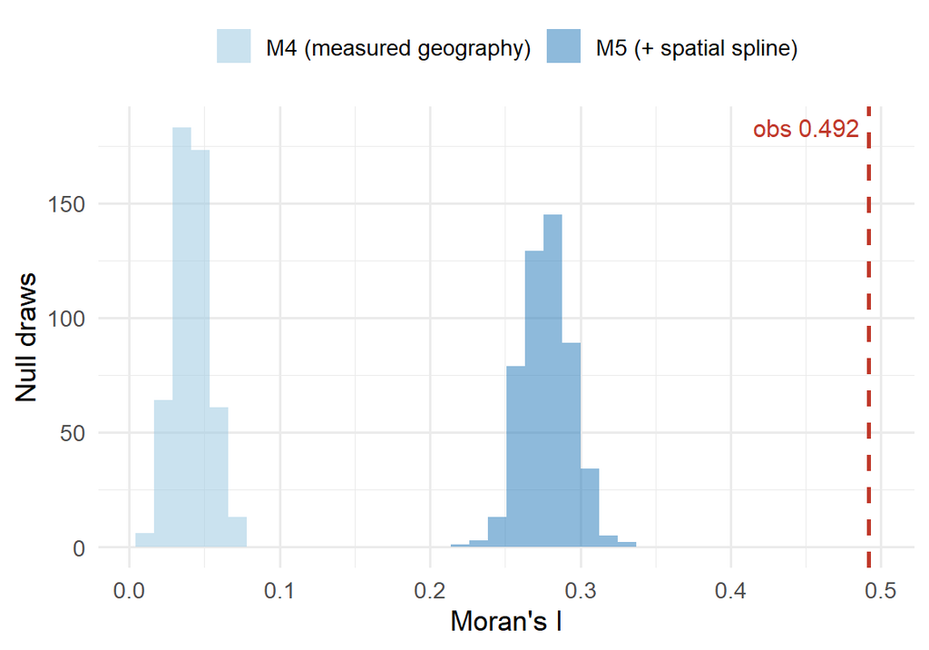

**Residual Moran’s I**

| Model | Resid. I | p |
| --- | --- | --- |
| M4 (measured geography) | 0.468 | 0 |
| M5 (+ spatial spline) | 0.203 | 0 |

## Mining Propensity Net of Measured Covariates

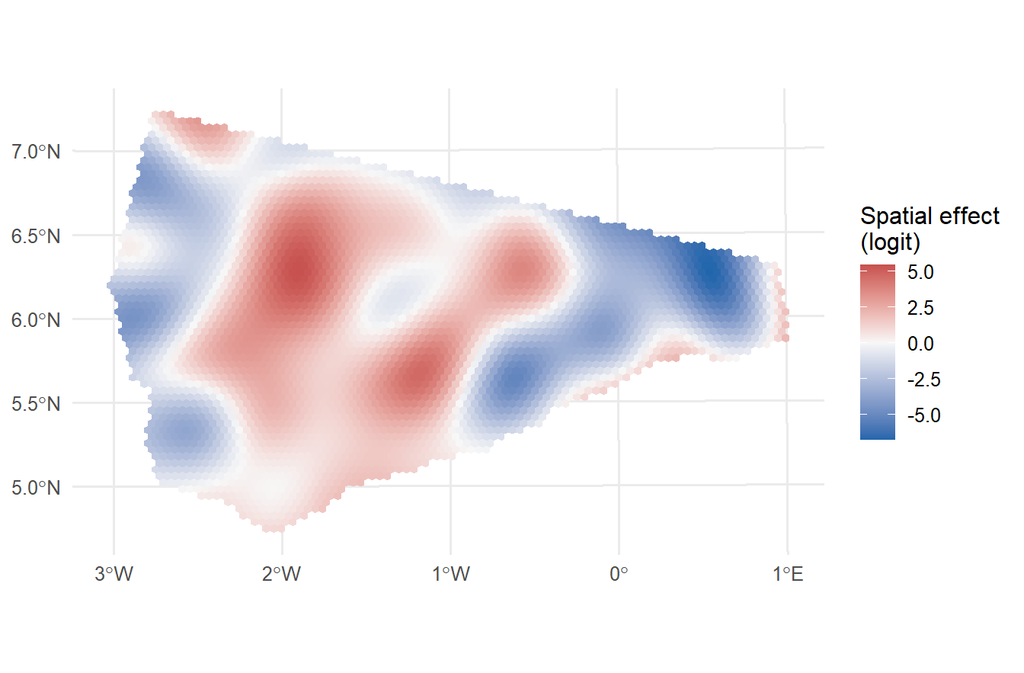

M5 spatial term *s*(easting, northing), 5 km hexagons, mean-centred logit. A pure function of location: **red** = more mining than geology/river/terrain predict at that hex; **blue** = less. The excess is *not* attributable to any smooth confounder.

## Summary: Part 3

- **Geography explains where, not how tightly.** Gold-suitable geology and river proximity are strong first-stage predictors of mine location — but adding richer geography (terrain, spatial lags, interactions: M1→M4) barely reduces excess clustering
- **Clustering survives the most conservative null.** An unrestricted thin-plate spline (M5), absorbing *all* smooth spatial variation in location, still leaves excess Moran’s I far above the geography null — *p*(excess) = 0 throughout
- **Neighbour stock predicts onset.** +10 ha of cumulative neighbour mining → +0.9 ha new mining that year; +50 ha raises probability of any onset by ~13 pp — within-hex and year fixed effects control for static geography and national shocks
- **Conclusion:** The spatial pattern is consistent with economic spillover processes. Geography alone cannot account for it; the causal channel and direction are tested in the event study

# Part 4

How does galamsey spread?

## Spatial Lag Model: Estimating Equation

$$\Delta y_{it} \;=\; \alpha_i \;+\; \gamma_t \;+\; \rho\;\bar{y}_{N(i),\,t-1} \;+\; \varepsilon_{it}$$

- $\Delta y_{it}$: new artisanal mining in hex $i$, year $t$ (hectares; or 0/1 indicator for LPM variant)
- $\bar{y}_{N(i),\,t-1}$: lagged *cumulative* mining stock in queen-contiguous neighbours of $i$ at end of $t-1$
- $\rho$: spatial spillover coefficient — does the stock of neighbour mining predict your new onset?
- $\alpha_i$: hex fixed effects — absorb all time-invariant geography (geology, soil, river distance)
- $\gamma_t$: year fixed effects — absorb national shocks (gold price, policy, rainfall)
- **Identification:** within-hex variation over time, conditional on national trends. Residual concern: time-varying *local* factors not captured by hex FE (e.g., new access roads).

## Spatial Lag Regression: Results

|  | New mining (ha) | Any new mining (LPM) |
| --- | --- | --- |
| Neighbour mining stock ($t-1$) | 0.0912*** | 0.00262*** |
|  | (0.0121) | (0.000302) |
| Hex fixed effects | Yes | Yes |
| Year fixed effects | Yes | Yes |
| Observations | 33,480 | 33,480 |
| R² | 0.513 | 0.672 |

`fixest::feols`, two-way FE, SEs clustered by hex. *** *p* < 0.01.

- **Intensive margin:** +10 ha of cumulative neighbour mining → +0.91 ha new mining this year ($t$ = 7.5, $p < 10^{-13}$)
- **Extensive margin (LPM):** +50 ha in neighbours → ~13 pp higher probability of any mine onset ($t$ = 8.8, $p < 10^{-17}$)
- Two-way FE absorbs static geography and national shocks; caveat: time-varying local confounders not ruled out.

## Event Study: Do Mining Spillovers Reduce Agricultural Productivity?

**Question:** does galamsey in *surrounding* hexes reduce agricultural productivity — measured by NDVI — in a focal hex?

- **Two candidate channels:**
  - **Land-use:** mining in *adjacent* hexes disturbs nearby land directly — e.g. access roads and worker camps spill over onto neighbouring hexagons
  - **Waterborne:** mining *upstream* releases sediment and mercury into rivers, degrading farmland **downstream**
- Distinguishing them requires *direction*, not just proximity: upstream vs downstream, not merely “nearby”.
- **Prediction (waterborne):** upstream mining onset → downstream NDVI decline. Downstream mining should *not* affect upstream NDVI — a built-in directional **placebo**.
- **Test:** Callaway–Sant’Anna staggered event study on a hex × year panel, using MERIT-derived river flow direction to define who is upstream of whom.

## Neighbour Roles Along the River Corridor

Each hex is classified *relative to a focal hex* using the river flow graph:

- **Upstream** (all-reachable + nearest 1-hop) — **treatment**: can contaminate the focal hex via water
- **Lateral** (queen-adjacent, off the flow path) — **comparison**: shares a border but no water link → isolates the pure land-use channel
- **Downstream** (1-hop + all-reachable) — **placebo**: cannot reach the focal hex via water; should be null

🔍 *Click the figure to enlarge.*

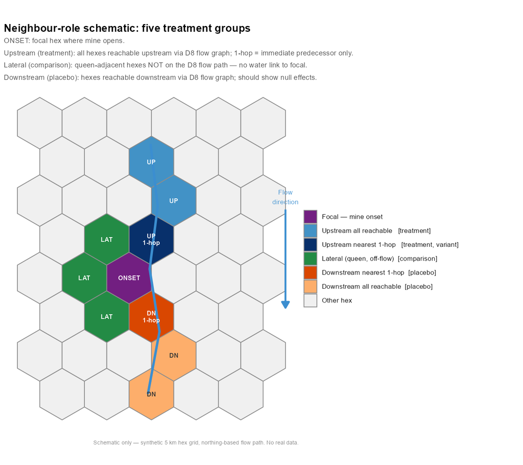

## Three Ways to Capture Rivers

“River” can mean three different things — each from a different data source:

1. **OSM waterways** — surveyed/digitised vector lines (river, stream, brook…) from OpenStreetMap. Captures *where rivers have been mapped*; coverage depends on contributor effort. → first-stage `dist_river_km`.
2. **MERIT Hydro** — a DEM-derived stream network from thresholding upstream drainage area (`upa` > 50 km²), *plus* the `dir` band, which routes each cell downslope into a **directed** flow graph. Captures not only where channels are but *which way water flows* — the basis for the upstream/downstream event study.
3. **Remotely sensed surface water** — rivers, ponds and pits detected directly from satellite imagery via water indices (MNDWI, Landsat/Sentinel-2). Observed water, seasonally resolved; part of our own RS pipeline (Part 1). *Not used so far.*

🔍 *Click the figure to enlarge.*

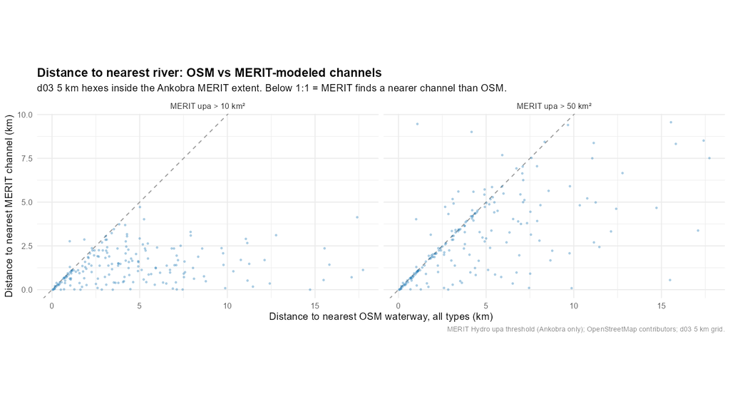

Ways 1 vs 2 disagree: per-hex distance to nearest OSM waterway vs nearest MERIT channel (Ankobra). Below the 1:1 line, MERIT finds a nearer channel than OSM has mapped.

## River Flow Direction from MERIT Hydro

**MERIT Hydro** (Yamazaki et al. 2019): global ~90 m hydrography derived from spaceborne DEMs. Two bands drive our routing:

- **`dir`** — D8 flow direction: each cell drains to one of its 8 neighbours
- **`upa`** — upstream drainage area (km²): larger = further down the channel

**D8 routing** chains these into a directed flow graph, aggregated to hexes → explicit **upstream/downstream** relations for every hex pair. Replaces the crude northing proxy used previously.

🔍 *Click the figure to enlarge.*

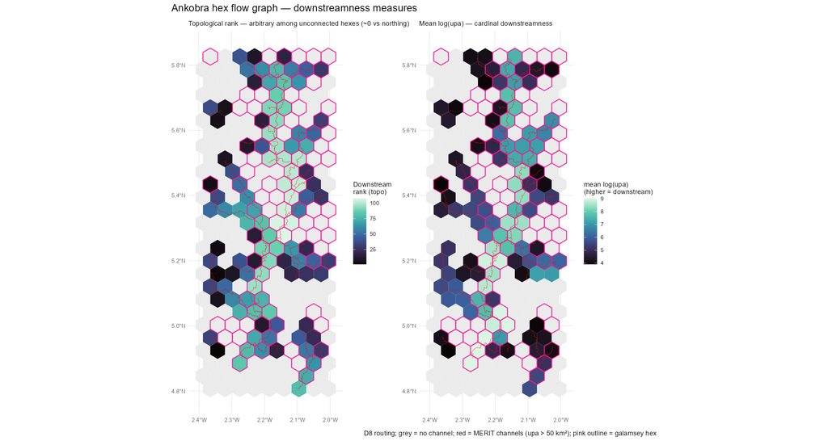

Ankobra basin. Downstreamness per hex: topological rank (left) and mean log upstream area (right). Red = MERIT channels (upa > 50 km²); pink outline = galamsey hex.

## The Channel Filter and Upstream Exposure

**Filter — route only along real channels.** A hex sources flow edges only from cells with upstream area **> 10 km²** (`ROUTE_KM2`). Without it, “flow” runs over ridges and hillslopes and leaks mining across drainage divides.

- 10 km² keeps **94.5%** of mined hectares on-network (the 50 km² “river” label drops 23%)
- Threshold swept over {2, 5, 10, 20} km² as a robustness check

**Upstream exposure** = total mining area draining *through* each hex via the flow graph (raw, and distance-decayed).

🔍 *Click the figure to enlarge.*

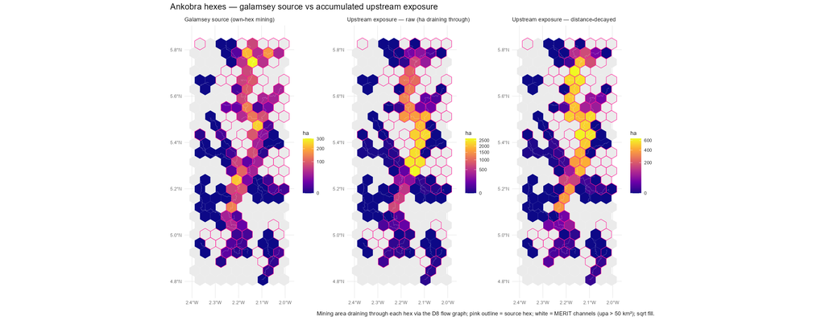

Own-hex galamsey (left) vs accumulated upstream mining draining through each hex, raw (centre) and distance-decayed (right). Exposure concentrates along the main Ankobra channel.

## The Hex × Year Panel

**Unit:** hex × year (built at 1, 2, and 5 km grids); **outcome:** MODIS NDVI per hex-year. For each **exposure dimension** the panel records new mining (ha/yr), cumulative **stock** (ha), and **onset year**:

| Dimension | How defined | Role |
| --- | --- | --- |
| Own | focal hex itself | outcome-side / censoring |
| Upstream — all / 1-hop | MERIT D8 flow graph | **treatment** |
| Lateral | queen-adjacent minus 1-hop up/down | comparison |
| Downstream — all / 1-hop | MERIT D8 flow graph | placebo |

- Directed columns come from the MERIT flow graph; lateral/adjacency from queen contiguity.
- **Also carried per hex-year — outcomes & controls:** MODIS + Landsat NDVI/EVI (plus cropland-masked *forest-crop* / *no-mine-crop* variants), terrain (elevation, slope), gold-suitable-geology share, distance-to-river, and a 25 km sub-basin block id for clustering SEs.
- Supports onset **clocks** (staggered DiD), stock **thresholds**, and distributed **lags** from one object.
- Usable window = NDVI ∩ Barenblitt overlap (**2007–2017**).

## Three Event-Study Designs

- **V1 — Continuous distributed lag (transparent; robustness).** Three specs on the annual panel: (i) **TWFE, flow only** — ΔNDVI on new upstream mining, lags 0–3; (ii) **TWFE, flow + stock** — adds a flexible control for the cumulative neighbour stock; (iii) **dCDH continuous-dose** on the annual upstream stock, which — unlike TWFE — is **robust to heterogeneous, dynamic treatment effects**. Estimators: `fixest::feols` (TWFE); `DIDmultiplegtDYN::did_multiplegt_dyn` (de Chaisemartin & D’Haultfœuille 2020, 2024). The dCDH dose is run on both the full and the pre-own-entry-censored panel.
- **V2 — Absorbing stock threshold (headline).** A hex is “treated” the first year its neighbour mining *stock* crosses $\bar m \in \{0, 10, 25, 50\}$ ha; NDVI in **levels**; the $\bar m$ sweep is the stability check. Estimator: `did::att_gt` → `aggte` — **Callaway & Sant’Anna (2021)**, not-yet-treated controls.
- **V3 — Nearest-upstream clock:**: not yet implemented

Estimators & literature: TWFE via `fixest`; heterogeneity-robust continuous-dose dCDH via `DIDmultiplegtDYN` (de Chaisemartin & D’Haultfœuille 2020, 2024) for V1; Callaway & Sant’Anna (2021) staggered DiD via `did` for V2–V3. Downstream onset = directional **placebo** throughout.

## Who Is in the Control Pool?

| category | n_hexes | n_total | share |
| --- | --- | --- | --- |
| **upstream — all reachable (treatment)** |  |  |  |
| Never mined themselves | 1101 | 1920 | 0.573 |
| Started mining after treatment onset | 450 | 1920 | 0.234 |
| Already mining when treatment started | 369 | 1920 | 0.192 |
| **upstream — 1-hop (treatment)** |  |  |  |
| Never mined themselves | 249 | 955 | 0.261 |
| Started mining after treatment onset | 213 | 955 | 0.223 |
| Already mining when treatment started | 493 | 955 | 0.516 |
| **lateral — queen minus 1-hop up/down (comparison)** |  |  |  |
| Never mined themselves | 808 | 1698 | 0.476 |
| Started mining after treatment onset | 376 | 1698 | 0.221 |
| Already mining when treatment started | 514 | 1698 | 0.303 |
| **downstream — 1-hop (placebo)** |  |  |  |
| Never mined themselves | 444 | 1283 | 0.346 |
| Started mining after treatment onset | 322 | 1283 | 0.251 |
| Already mining when treatment started | 517 | 1283 | 0.403 |
| **downstream — all reachable (placebo)** |  |  |  |
| Never mined themselves | 3654 | 4679 | 0.781 |
| Started mining after treatment onset | 732 | 4679 | 0.156 |
| Already mining when treatment started | 293 | 4679 | 0.063 |

Own-mining composition of ever-treated hexes, per treatment definition. **Never mined themselves** = cleanest spillover sample; **started after treatment onset** = clean at onset, endogenously treated later; **already mining** = contaminated. `n_total` = all ever-treated hexes for that definition.

## Treatment Timing — Upstream Panelviews

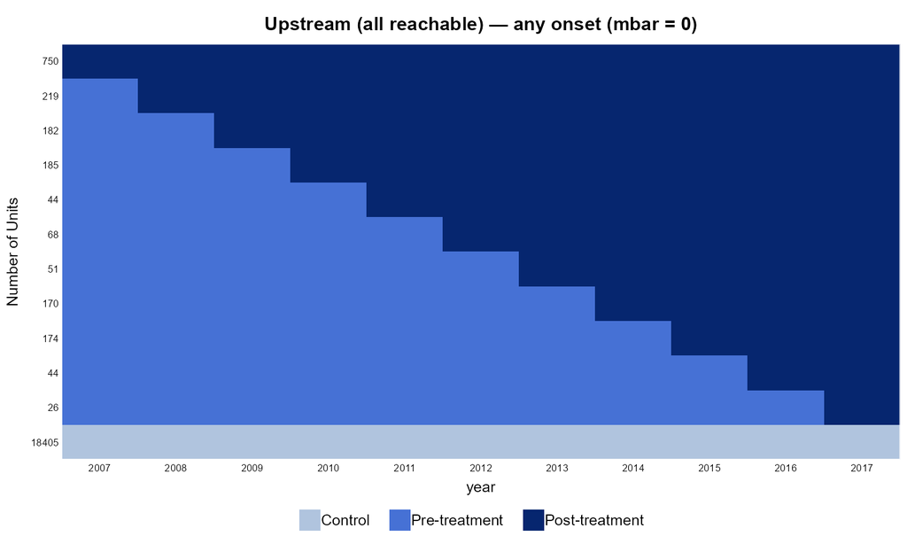

$\bar m = 0$ — any upstream onset (V3 trigger).

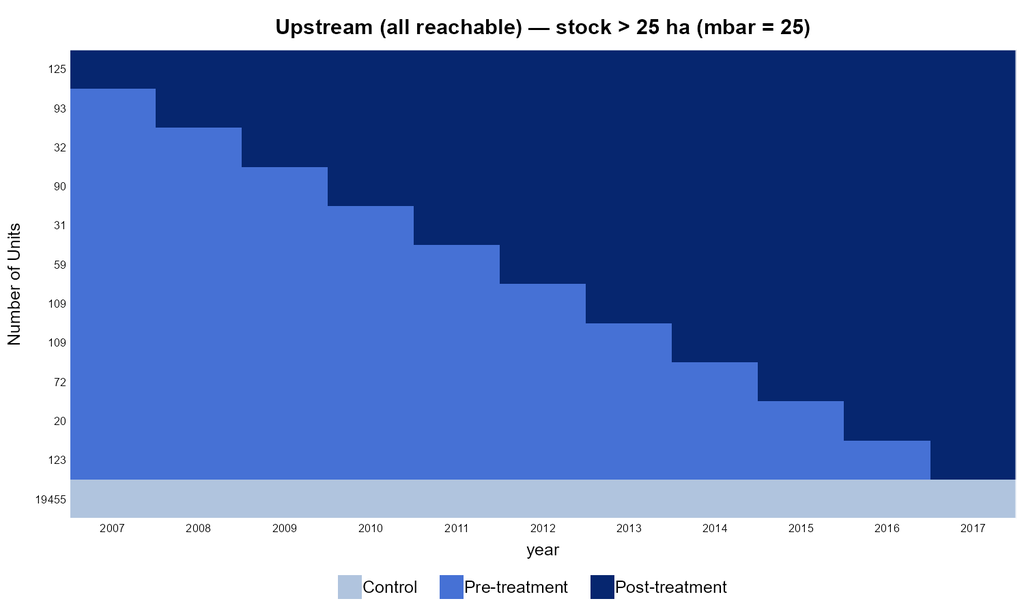

$\bar m = 25$ ha — a V2 stock threshold (later, fewer treated).

Treatment-timing structure (all-reachable upstream stock crossing $\bar m$). 🔍 *Click a figure to enlarge.*

## Version 1 — dCDH: Upstream Stock → NDVI

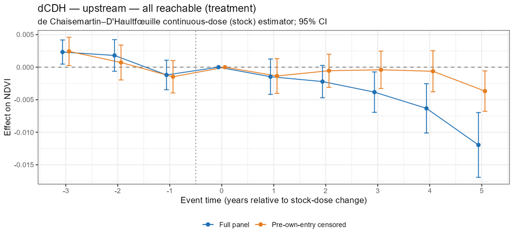

de Chaisemartin–D’Haultfœuille continuous-dose estimator on the annual upstream mining **stock** — heterogeneity- and dynamics-robust. Full panel vs pre-own-entry censored; 95% CI. Effect_ℓ = post, Placebo_ℓ = pre.

## Version 1 — Comparison & Placebo

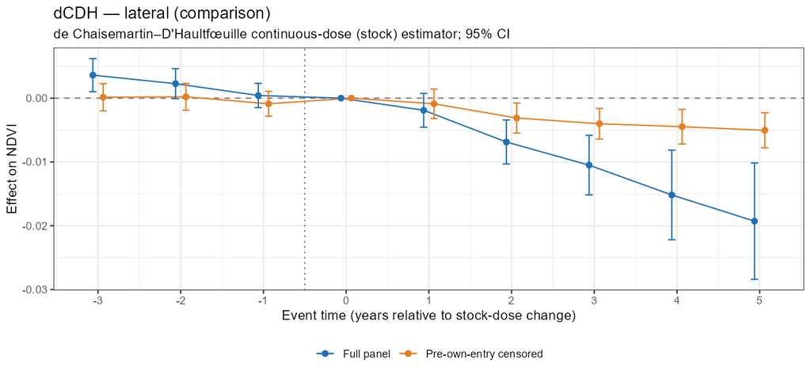

**Lateral (comparison)** — queen off-flow: land-use channel only.

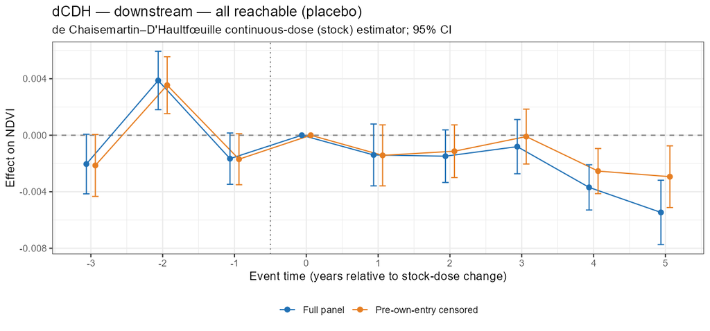

**Downstream (placebo)** — should be null if the channel is waterborne.

Same dCDH continuous-dose design as the headline upstream result, applied to the lateral and downstream stock. 🔍 *Click a figure to enlarge.*

## Version 1 — Nearest-Hop: Upstream & Downstream

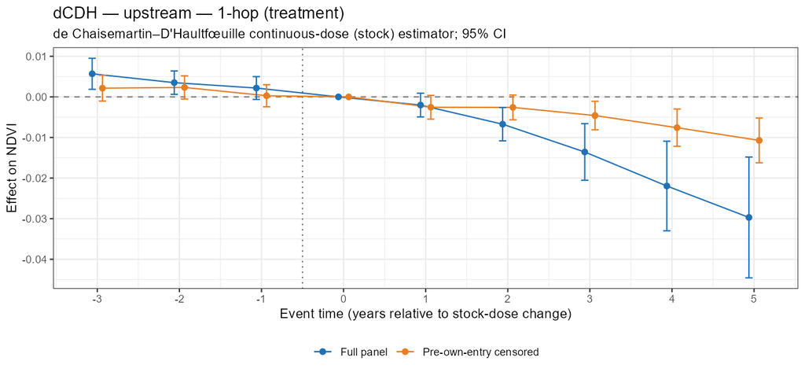

**Upstream — 1-hop (treatment)** — nearest upstream neighbour only.

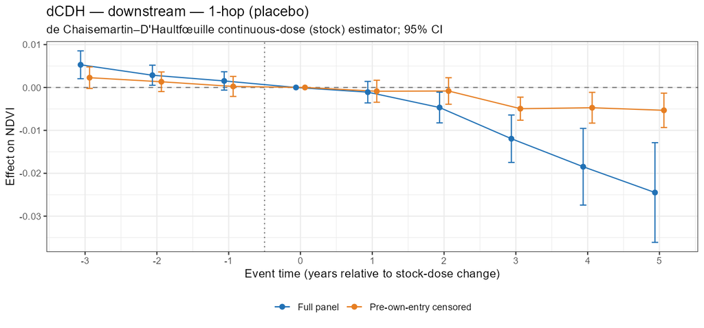

**Downstream — 1-hop (placebo)** — nearest downstream neighbour only.

Restricting the flow-graph exposure to the single nearest upstream/downstream hex, rather than all reachable hexes. 🔍 *Click a figure to enlarge.*

## Version 1 — dCDH: Summary

| panel | ATE [95% CI] | p(pre-trend) | p(effects) | switchers |
| --- | --- | --- | --- | --- |
| **upstream — all reachable (treatment)** |  |  |  |  |
| Full panel | -0.0002 [-0.0004, -0.0001] | 0.000 | 0.000 | 9560 |
| Pre-own-entry censored | -0.0001 [-0.0004, 0.0001] | 0.001 | 0.031 | 6874 |
| **upstream — 1-hop (treatment)** |  |  |  |  |
| Full panel | -0.0029 [-0.0043, -0.0014] | 0.006 | 0.004 | 4775 |
| Pre-own-entry censored | -0.0032 [-0.0052, -0.0012] | 0.243 | 0.009 | 1809 |
| **lateral (comparison)** |  |  |  |  |
| Full panel | -0.0020 [-0.0029, -0.0011] | 0.019 | 0.000 | 8480 |
| Pre-own-entry censored | -0.0013 [-0.0021, -0.0005] | 0.654 | 0.005 | 5150 |
| **downstream — 1-hop (placebo)** |  |  |  |  |
| Full panel | -0.0023 [-0.0034, -0.0012] | 0.002 | 0.001 | 6415 |
| Pre-own-entry censored | -0.0014 [-0.0025, -0.0002] | 0.171 | 0.001 | 3100 |
| **downstream — all reachable (placebo)** |  |  |  |  |
| Full panel | -0.0001 [-0.0001, -0.0000] | 0.000 | 0.000 | 23395 |
| Pre-own-entry censored | -0.0001 [-0.0001, -0.0000] | 0.000 | 0.014 | 20908 |

ATE = average total effect on NDVI; **p(pre-trend)** high = flat pre-trends (design credible); **p(effects)** low = dynamic effects jointly significant; Switchers = hexes identifying the ATE.

## Version 2 — Upstream Stock Threshold → NDVI (headline)

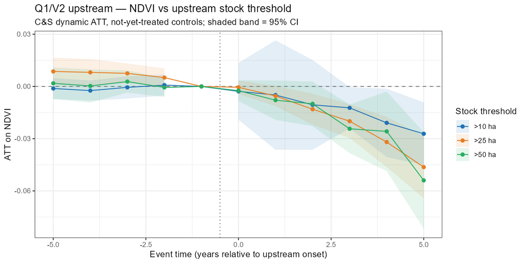

## Version 2 — Comparison & Placebo

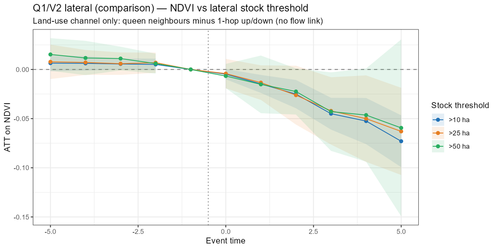

**Lateral (comparison)** — queen off-flow: land-use channel only.

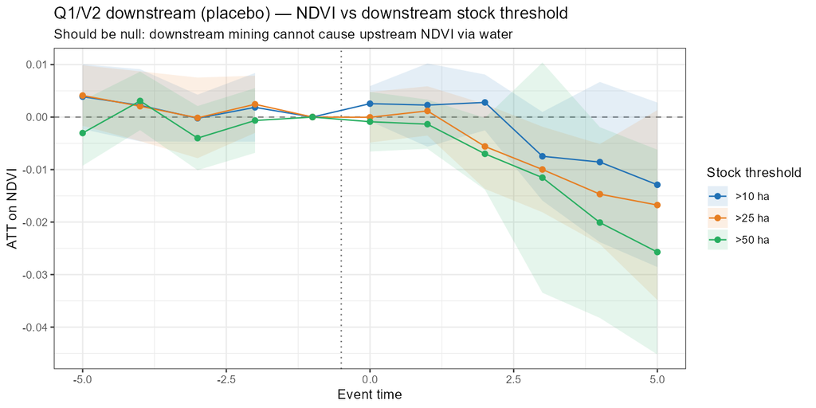

**Downstream (placebo)** — should be null if the channel is waterborne.

🔍 *Click a figure to enlarge.*

## Version 2 — Nearest-Hop: Upstream & Downstream

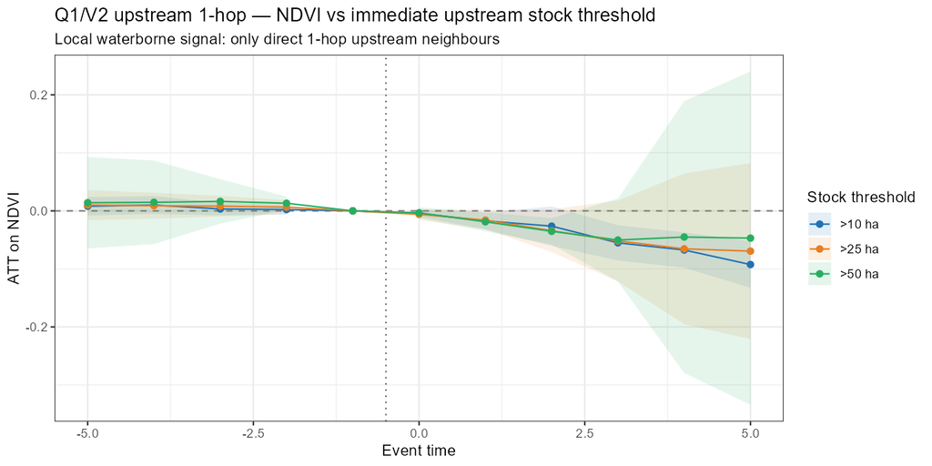

**Upstream — 1-hop (treatment)** — nearest upstream neighbour only.

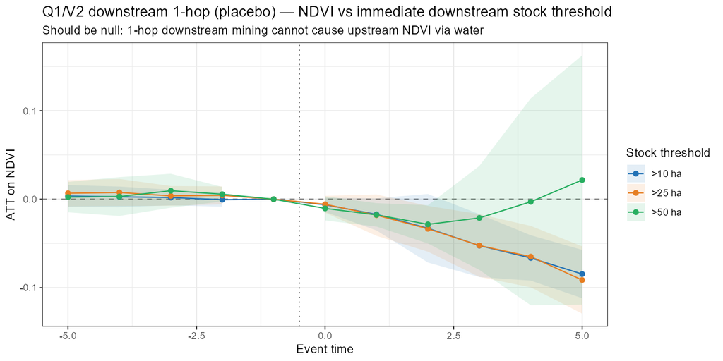

**Downstream — 1-hop (placebo)** — nearest downstream neighbour only.

C&S dynamic ATT restricted to the single nearest upstream/downstream hex, rather than all reachable hexes. 🔍 *Click a figure to enlarge.*

## Version 2 — ATT Across Thresholds & Exposures

| mbar | att | se | ci_lo | ci_hi |
| --- | --- | --- | --- | --- |
| **upstream — all reachable (treatment)** |  |  |  |  |
| mbar_0 | -0.01 | 0.0031 | -0.0162 | -0.0039 |
| mbar_10 | -0.0115 | 0.0174 | -0.0456 | 0.0226 |
| mbar_25 | -0.0207 | 0.0043 | -0.0292 | -0.0122 |
| mbar_50 | -0.0146 | 0.0053 | -0.025 | -0.0043 |
| **upstream — 1-hop (treatment)** |  |  |  |  |
| mbar_0 | -0.0186 | 0.0043 | -0.027 | -0.0103 |
| mbar_10 | -0.0255 | 0.0081 | -0.0413 | -0.0097 |
| mbar_25 | -0.0205 | 0.0138 | -0.0476 | 0.0066 |
| mbar_50 | -0.0142 | 0.0113 | -0.0365 | 0.008 |
| **lateral (comparison)** |  |  |  |  |
| mbar_0 | -0.0145 | 0.011 | -0.036 | 0.0071 |
| mbar_10 | -0.021 | 0.0053 | -0.0314 | -0.0106 |
| mbar_25 | -0.0184 | 0.0149 | -0.0476 | 0.0107 |
| mbar_50 | -0.0149 | 0.0102 | -0.0349 | 0.0051 |
| **downstream — 1-hop (placebo)** |  |  |  |  |
| mbar_0 | -0.0144 | 0.005 | -0.0243 | -0.0046 |
| mbar_10 | -0.027 | 0.0129 | -0.0524 | -0.0016 |
| mbar_25 | -0.0236 | 0.013 | -0.049 | 0.0019 |
| mbar_50 | -0.0141 | 0.0103 | -0.0343 | 0.0061 |
| **downstream — all reachable (placebo)** |  |  |  |  |
| mbar_0 | -0.0084 | 0.0064 | -0.0209 | 0.0042 |
| mbar_10 | -0.0043 | 0.0024 | -0.0089 | 4e-04 |
| mbar_25 | -0.0084 | 0.0035 | -0.0153 | -0.0015 |
| mbar_50 | -0.0144 | 0.0052 | -0.0247 | -0.0042 |

Overall ATT on NDVI by exposure dimension and stock threshold. Treatment (upstream) should be negative; lateral = land-use comparison; downstream = placebo (≈ 0).

# Motivating Facts

What triggers galamsey? What are its agricultural impacts?

## National Trend vs Gold Price

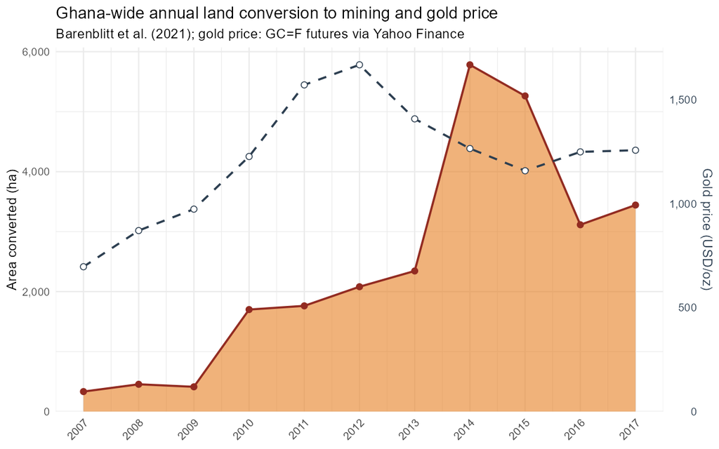

Annual new galamsey conversion (ha) alongside international gold price (USD/troy oz). The 2007–2012 price boom coincides with a marked acceleration in mining activity — consistent with economic incentives driving entry.

## Instruments: Exogenous Variation in Mining

**Problem.** Mine location is *endogenous* — miners dig where returns are highest, which correlates with local economic and agricultural conditions. Identifying mining’s causal effect needs variation in mining *not* driven by those conditions.

**Logic.** Galamsey is **alluvial (placer)** mining: miners follow where eroded gold physically settles. Geomorphology and geology predict those deposition sites and are fixed by nature — plausibly shifting mining (**relevance**) while affecting farm productivity and downstream outcomes *only through* mining (**exclusion**).

- **Gold-suitable geology** (Girard) — bedrock predisposed to host gold.
- **HAND** (Height Above Nearest Drainage) — low = active floodplain / river terraces where alluvium and gold accumulate.
- **MRVBF** (valley-bottom flatness) — broad flat valley floors act as sediment traps.
- **Stream Power Index** $=\ln(\text{catchment area}\times\tan\text{slope})$ — low SPI on a channel = low-energy reach where heavy minerals drop out.
- **Stream Transport Index** — sediment-transport capacity from slope × upslope area; where it falls, sediment (and gold) deposits.

Caveat: exclusion is an *assumption*, not a fact — valley bottoms are also prime farmland, so terrain may affect agriculture directly. Treated as candidates to test, not settled instruments. (See `d_06_gold_deposits.R` / `gold_deposits.md`.)

## Next Steps

**In progress**

- **Event study results** (`a_05_event_study.Rmd`): panel ready at 1/2/5 km; estimate and interpret Q1 (upstream→NDVI) and Q2 (mining contagion) with Callaway–Sant’Anna

**Empirical gaps — data needed**

- **Formal mine trigger** (D3c): Minerals Commission historical licence series
- **Reversion** (D4a): RS panel with annual mine *presence* (not just onset)
- **Cocoa yields** (D5c): COCOBOD district purchases
- **Labour reallocation** (D6a–D6c): Ghana census microdata (IPUMS / GSS)
- **Climate shocks** (D3b): CHIRPS annual rainfall merge

**Methodological**

- **Dataset construction** (D7a–D7c): hexagon or enumeration-area panel combining mining intensity, NDVI/EVI, and census variables

# Annex

Additional figures

## Annex: Cumulative Mining Extent — Districts

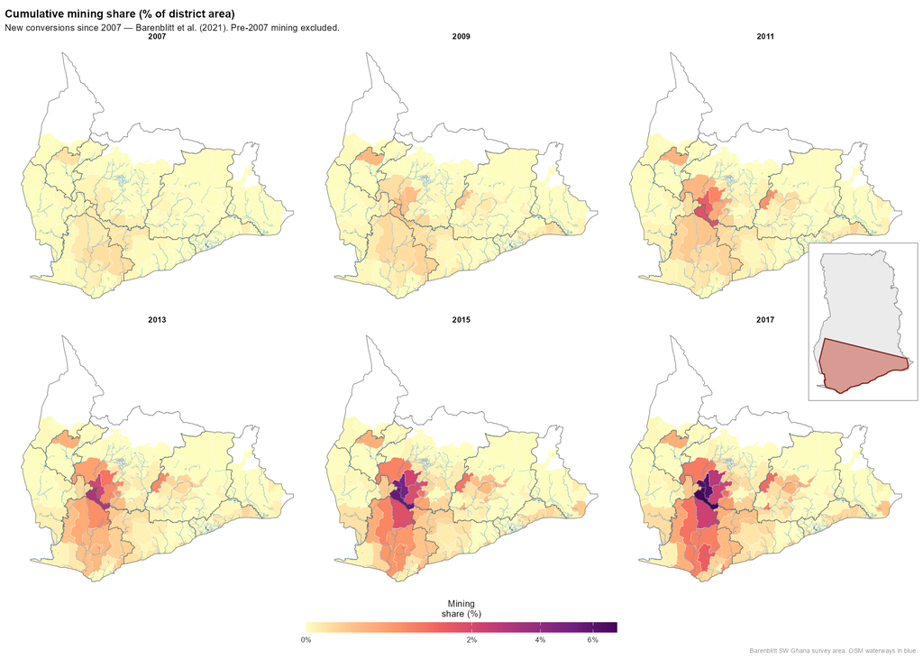

## Annex: Artisanal vs Industrial Mining — Districts

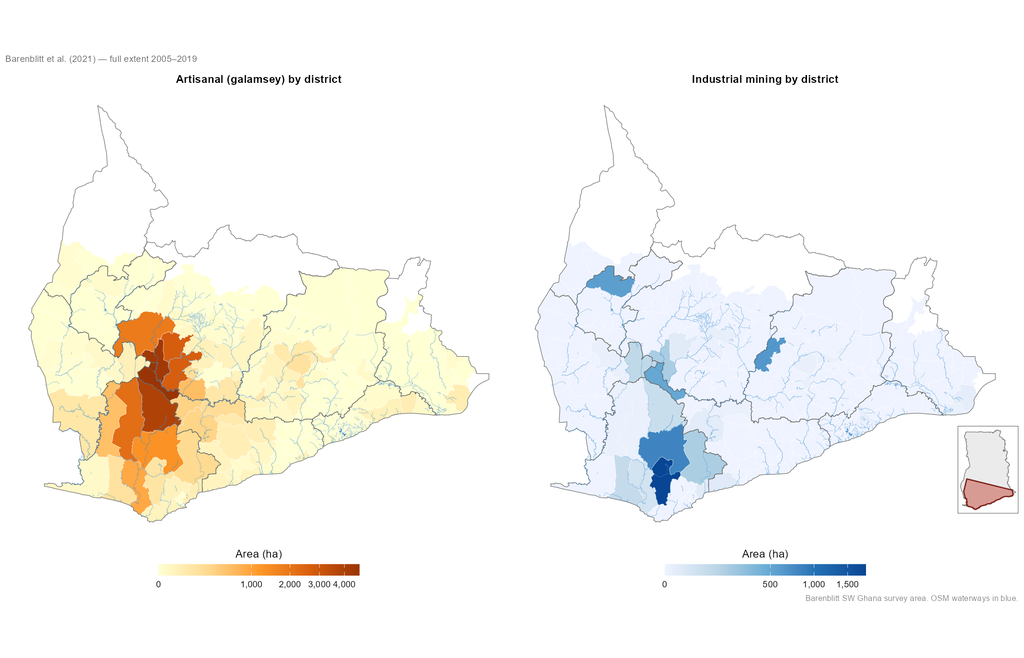

Left: artisanal (galamsey). Right: industrial (formal). Note the divergent spatial footprints. Barenblitt 2019 extent.

## Annex: Top Districts by Mining Extent

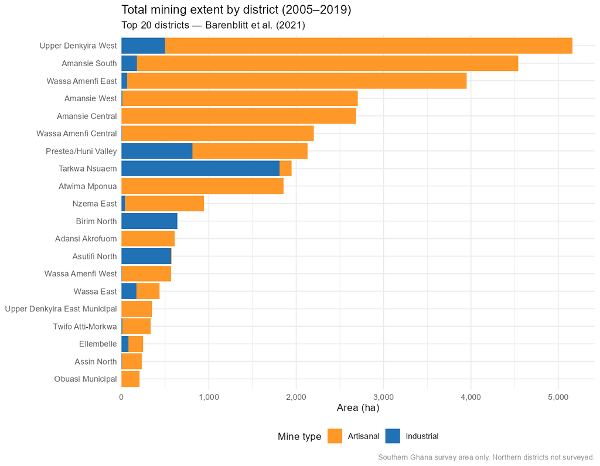

## Annex: District Trajectories Over Time

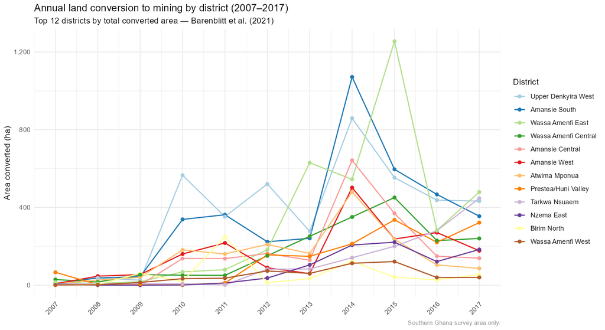

Annual new conversion (ha) for the 12 districts with highest cumulative extent. Onset years and growth rates vary considerably across districts.